# Linear models

Dmitry Kondrashov & Stefano Allesina

Fundamentals of Biological Data Analysis – BIOS 26318

# Goal

Learn how to perform linear regression, how to make sure that the assumptions of the model are not violated, and how to interpret the results.

# Regression toward the mean

Francis Galton (Darwin’s half-cousin) was a biologist interested in evolution, and one of the main proponents of eugenics (he coined the term himself). To advance his research program, he set out to measure several features in human populations, and started trying to explain the variation he observed, incidentally becoming one of the founding fathers of modern statistics.

In his “Regression towards mediocrity in hereditary stature” he showed an interesting pattern: children of tall parents tended to be shorter than their parents, while children of short parents tended to be taller than their parents. He called this phenomoenon “regression toward mediocrity” (now called regression toward [to] the mean).

We’re going to explore this phenomenon using Karl Pearson’s (another founding father of statistics) data from 1903, recording the height of fathers and sons:

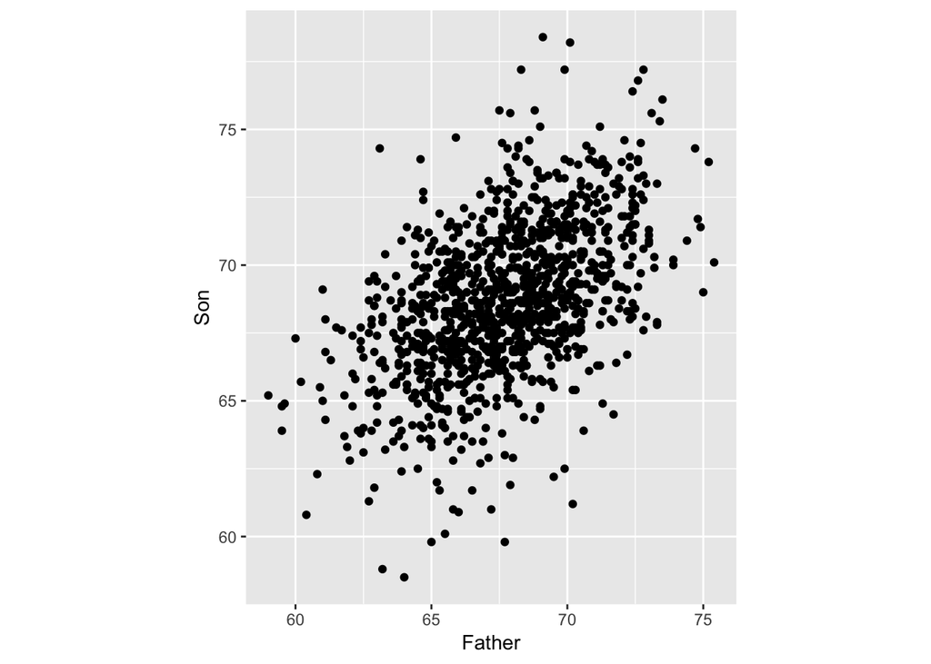

```r
library(tidyverse)
heights <- read_tsv("http://www.randomservices.org/random/data/Pearson.txt")
pl <- ggplot(data = heights) + aes(x = Father, y = Son) + geom_point() + coord_equal()
pl
```

Let’s add the 1:1 line for comparison:

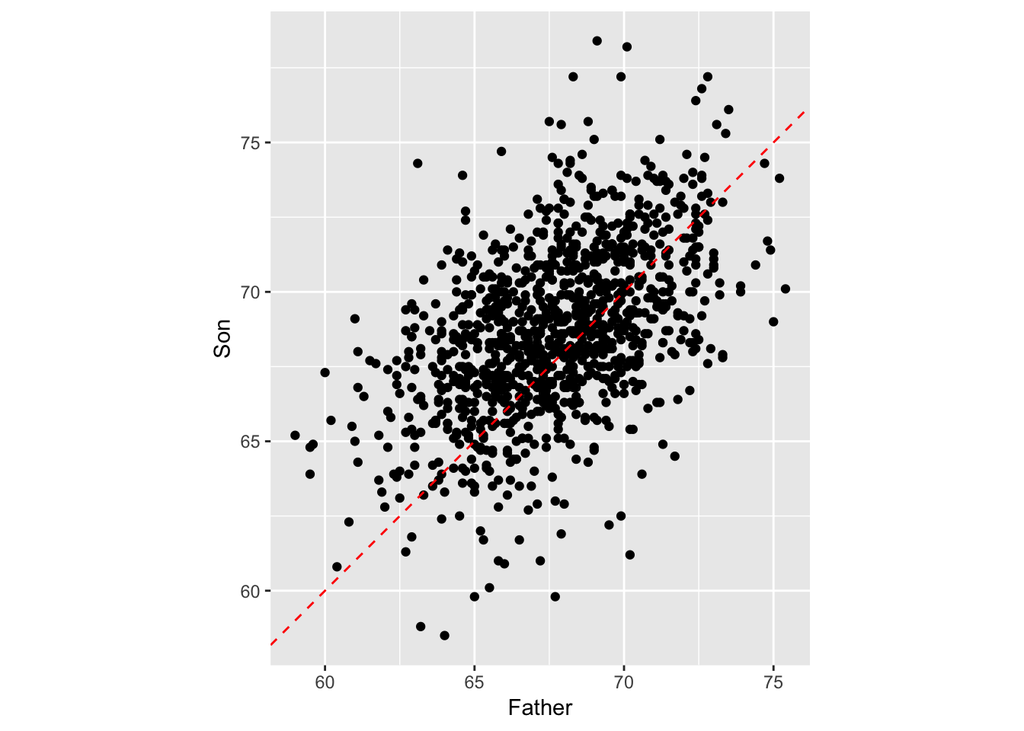

```r
pl + geom_abline(slope = 1, intercept = 0, linetype = 2, color = "red")
```

You can see that the sons tend to be taller than their fathers. Let’s see of how much:

```r
mean(heights$Father)
mean(heights$Son)
# difference
mean(heights$Son) - mean(heights$Father)
```

```
# [1] 67.68683
# [1] 68.68423
# [1] 0.9974026
```

So let’s add a line with an intercept of 1:

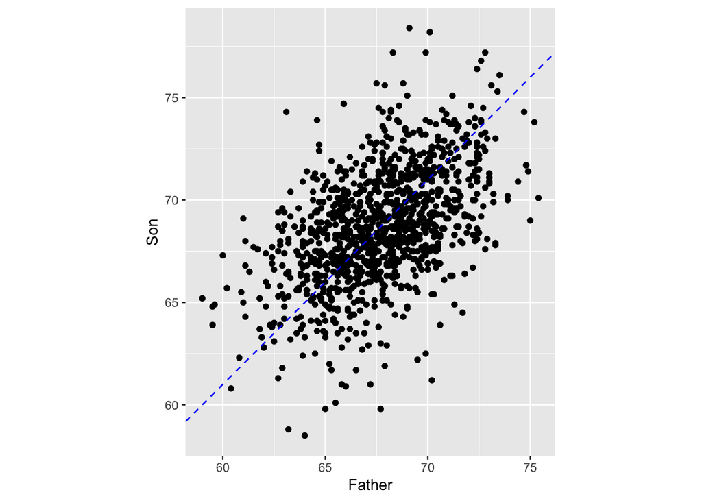

```r
pl <- pl + geom_abline(slope = 1, intercept = 1, linetype = 2, color = "blue")
pl
```

You can see that the line does not divide the cloud of points evenly: even though tall fathers tend to produce tall sons, and short fathers short sons, the sons of short fathers tend to be taller than their fathers (for example, look at the sons of fathers less than 60 inches tall), while the sons of tall fathers tend to be shorter than their fathers (for example, the sons of fathers taller than 75 inches).

This phenomenon is called “regression toward the mean”: when you take two measurement on the same sample (or related samples, as here), if a variable is extreme on its first measurement, it will tend to be closer to the average on its second measurement; if it is extreme on its second measurement, it will tend to have been closer to the average on its first.

> **Regression to the mean: dangers of interpretation**
- A city sees an unusual growth of crime in a given neighborhood, and they decide to patrol the neighborhood more heavily. The next year, crime rates are close to normal. Was this due to heavy presence of police?
- A teacher sees that scolding students who’ve had a very low score in a test makes them perform better in the next test. (But would praising those with unusually high scores lead to slacking off in the next test?)
- A huge problem in science: effect sizes tend to decrease through time. Problem of selective reporting?

This phenomemon gave the name to one of the simplest statistical models: the linear regression.

# Finding the best fitting line: Linear Regression

How can we explain the relationship between the height of the faters and those of their sons? One of the simplest models we can use is called a “Linear Model”. Basically, we want to express the height of the son as a function of the height of the father:
$$y_i = \beta_0 + \beta_1 x_i + \epsilon_i$$
where $y_i$ is the height of the son (**response variable**), $x_i$ is the height of the father (**explanatory variable**), $\beta_0$ and $\beta_1$ are two numbers (intercept and slope of the line) that do not vary within the population (these are the parameters we want to fit). Finally, the term $\epsilon_i$ measures the “error” we are making for the $i^{th}$ son. For simplicity, we assume the $\epsilon_i \overset{\text{iid}}{\sim} \mathcal N(0, \sigma^2)$ (and $\sigma$ is therefore another parameter we want to fit).

When we have multiple explanatory variables (for example, if we had recorded also the height of the mother, whether the son was born at full term or premature, the average caloric intake for the family, etc.), we speak of **Multiple Linear Regression**:

$$y_i = \beta_0 + \sum_{k=1}^n \beta_k x_{ik} + \epsilon_i$$

## Solving a linear model — some linear algebra

In this section, we’re going to look at the mechanics of linear regression. Let us start with the simple example of two data points, in which case its slope and intercept can be found by solving the two simultaneous linear equations.

**Example:** If the data set consists of $(3,5), (6, 2)$, then finding the best fit values of $m$ and $b$ means solving the following two equations:

$$3m + b = 5$$
$$6m + b = 2$$

These equations have a solution for the slope and intercept, which can be calculated in R using solve():

```r
A <- matrix(c(3,6,1,1), nrow = 2)
b = c(5,2)
solve(A,b)
```

```
# [1] -1  8
```

However, a data set with two points is very small and nobody would accept these values as reasonable estimates. Let us add one more data point, to increase our sample size to three: $(3,5, (6, 2), (9, 1)$. How do you find the best fit slope and intercept?

**Bad idea:** take two points and find a line, that is the slope and the intercept, that passes through the two. It should be clear why this is a bad idea: we are arbitrarily ignoring some of the data, while perfectly fitting two points. So how do we use all the data? Let us write down the equations that a line with slope $m$ and intercept $b$ have to satisfy in order to fit our data points:
$$3m + b = 5$$
$$6m + b = 2$$
$$9m + b = 1$$

This system has no exact solution, since there are three equations and only two unknowns. We need to find $m$ and $b$ such that they are a “best fit” to the data, not the perfect solution. To do that, we need to define what we mean by the *goodness of fit*.

## Defining goodness of fit

One simple way to asses how close the fit is to the data is to subtract the predicted values of $y$ from the data, as follows: $e_i = y_i - (mx_i + b)$. The values $e_i$ are called the *errors* or *residuals* of the linear fit. If the values predicted by the linear model ($mx_i+b$) are close to the actual data $y_i$, then the error will be small. However, if we add it all up, the errors with opposite signs will cancel each other, giving the impression of a good fit simply if the deviations are symmetric.

A more reasonable approach is to take absolute values of the deviations before adding them up. This is called the total deviation, for $n$ data points with a line fit:

$$TD = \sum_{i=1}^n | y_i - mx_i - b |$$
Mathematically, a better measure of total error is a sum of squared errors, which also has the advantage of adding up nonnegative values, but is known as a better measure of the distance between the fit and the data (think of Euclidean distance, which is also a sum of squares) :

$$SSE = \sum_{i=1}^n ( y_i - mx_i - b )^2$$

Thus we have formulated the goal of fitting the best line to a two-variable data set, also known as linear regression: **find the values of slope and intercept that result in the lowest possible sum of squared errors**.

## Normal equations

Now we can generalize the calculation we saw above using linear algebra. Assu that for simplicity we have a single explanatory variable, then we can write the linear model in compact form as:
$$\mathbf{Y} = \mathbf{X} \mathbf{\beta} + \mathbf{\epsilon}$$
where:
$$\mathbf{Y} = \begin{pmatrix} y_1\\ y_2\\ \vdots \\ y_n \end{pmatrix} \;\;\;
\mathbf{X} = \begin{pmatrix} 1 & x_1\\ 1 & x_2\\ \vdots & \vdots \\ 1 & x_n \end{pmatrix}
\;\;\;
\mathbf{\beta} = \begin{pmatrix} \beta_0 \\ \beta_1\end{pmatrix} \;\;\; \mathbf{\epsilon} = \begin{pmatrix} \epsilon_1 \\ \epsilon_2 \\ \vdots \\ \epsilon_n \end{pmatrix}$$

Solving the linear regression means finding the best-fitting $\beta_0$, $\beta_1$ and $\sigma$ (controlling the spread of the distribution of the $\epsilon_i$). Our goal is to find the values of $\beta$ that minimize $\sigma$ (meaning that the points fall closer to the line). Rearranging:
$$\sum_i \epsilon_i^2 = \sum_i (y_i - \beta_0 - \beta_1 x_i)^2 = \Vert \mathbf{Y} - \mathbf{X} \mathbf{\beta} \Vert$$

As such, we want to find the vector $\beta$ that minimizes the norm $\Vert \mathbf{Y} - \mathbf{X} \mathbf{\beta} \Vert$. One can prove that this is accomplished using:
$$\hat{\mathbf{\beta}} = \left( \mathbf{X}^T \mathbf{X} \right)^{-1} \mathbf{X}^T \mathbf{Y}$$

Where the matrix $\left( \mathbf{X}^T \mathbf{X} \right)^{-1} \mathbf{X}^T$ is known as the (left) Moore-Penrose pseudo-inverse of $\mathbf{X}$. Let’s try to do this in `R` (the “hard” way):

```r
X <- cbind(1, heights$Father)
Y <- cbind(heights$Son)
best_beta <- solve(t(X) %*% X) %*% t(X) %*% Y
best_beta
```

```
#            [,1]
# [1,] 33.8928005
# [2,]  0.5140059
```

We find that the best fitting line has an intercept of about 34 inches, and a slope of 0.51. Of course, `R` can do this calculation for you with just one command:

```r
best_beta_easy <- lm(Son ~ Father, data = heights)
best_beta_easy
```

```
#
# Call:
# lm(formula = Son ~ Father, data = heights)
#
# Coefficients:
# (Intercept)       Father
#      33.893        0.514
```

But it feels good to know that this is not black magic! In fact, plotting it on top of the data does not even require computing the coefficients:

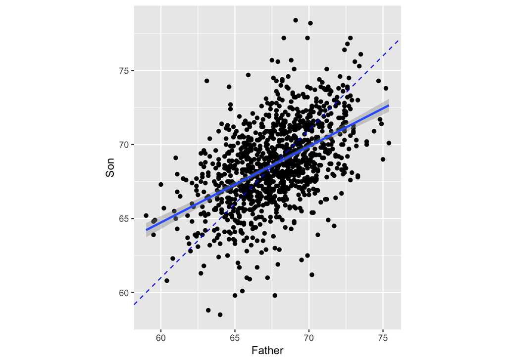

```r
pl + geom_smooth(method = "lm") # lm stands for linear model
```

This calculation can be reproduced by starting with the descriptive statistics of the explanatory and response data vriables. The slope calcalated above is determined by the covariance of the two variables divided by the variance of $X$:

$$m = \frac{Cov(X,Y)}{Var(X)}$$
And the intercept has the following relationship:

$$b = \bar Y - \frac{Cov(X,Y) \bar X}{Var(X)}$$
We can calculate these for the data set of heights of fathers and sons and see that they agree with the ones computer above:

```r
data.X <- heights$Father
data.Y <- heights$Son
m <- cov(data.X ,data.Y)/var(data.X)
b <- mean(data.Y) - m*mean(data.X)
paste ("The slope is", m, "and the intercept is", b)
```

```
# [1] "The slope is 0.514005912545592 and the intercept is 33.8928005406617"
```

## Minimizing the sum of squares

The calculation above is known as solving the system of equations in “the least-square sense”: we are trying to minimize the distance from the data points to their projection on the best-fitting line. We can compute the “predicted” heights as:
$$\hat{\mathbf{Y}} = \mathbf{X}\hat{\mathbf{\beta}}$$

Then, we’re minimizing $\Vert \mathbf{Y} - \hat{\mathbf{Y}}\Vert$. We call $\hat{\mathbf{\epsilon}} = \mathbf{Y} - \hat{\mathbf{Y}}$ the vector of **residuals**. From this, we can estimate the final parameter, $\sigma$:

$$\sigma = \sqrt{\frac{\sum_i \hat{\epsilon_i}^2}{n - p}}$$
where $n$ is the number of data points, and $p$ is the number of parameters in $\mathbf{\beta}$ (2 in this case); this measures the number of **degrees of freedom**. Let’s try to compute it:

```r
degrees_of_freedom <- length(Y) - 2
degrees_of_freedom
epsilon_hat <- X %*% best_beta - Y
sigma <- sqrt(sum(epsilon_hat^2) / degrees_of_freedom)
sigma
```

```
# [1] 1076
# [1] 2.438134
```

In `R`, you will find this reported as the `Residual standard error` when you call `summary` on your model:

```r
summary(best_beta_easy)
```

```
#
# Call:
# lm(formula = Son ~ Father, data = heights)
#
# Residuals:
#     Min      1Q  Median      3Q     Max
# -8.8910 -1.5361 -0.0092  1.6359  8.9894
#
# Coefficients:
#             Estimate Std. Error t value Pr(>|t|)
# (Intercept) 33.89280    1.83289   18.49   <2e-16 ***
# Father       0.51401    0.02706   19.00   <2e-16 ***
# ---
# Signif. codes:  0 '***' 0.001 '**' 0.01 '*' 0.05 '.' 0.1 ' ' 1
#
# Residual standard error: 2.438 on 1076 degrees of freedom
# Multiple R-squared:  0.2512,  Adjusted R-squared:  0.2505
# F-statistic: 360.9 on 1 and 1076 DF,  p-value: < 2.2e-16
```

The most important parameter of linear regression is the *correlation coefficient* $R$ and its cousin the *coefficient of determination* $R^2$. The correlation between two random variables is a measure of how much variation in one corresponds to variation in the other. If this sounds very similar to the description of covariance, it’s because they are closely related. Essentially, correlation is a “normalized” covariance, made to range between -1 and 1. Here is the definition:

> The linear (or Pearson) correlation of a dataset of pairs of data values $(X,Y)$ is:
> $$r = \frac{Cov(X,Y)}{\sqrt{{Var(X)}{Var(Y)}}} = \frac{Cov(X,Y)}{\sigma_X \sigma_Y}$$

The correlation coefficient is used a lot, but the most useful descriptor of quality of a linear fit is the coefficient of determination, because it measures **the fraction of variance of $Y$ explained by the linear model**:

$$R^2 = \frac{\sum_i (\hat{y}_i - \bar{y})^2}{\sum_i ({y}_i - \bar{y})^2}$$
where $\bar{y}$ is the mean of $y_i$. If the regression has an intercept, then the $R^2$ can vary between 0 and 1, with values close to 1 indicating a good fit to the data. Let us compare the coefficient of determination from definition with fraction of the variance explained by the regression:

```r
R <- cov(data.X,data.Y)/sqrt(var(data.X)*var(data.Y))
print (R^2)
y_bar <- mean(data.Y)
frac_explained <- sum((X %*% best_beta - y_bar)^2) / sum((Y - y_bar)^2)
print(frac_explained)
```

```
# [1] 0.251164
# [1] 0.251164
```

```r
# look for Multiple R-squared:
summary(best_beta_easy)
```

```
#
# Call:
# lm(formula = Son ~ Father, data = heights)
#
# Residuals:
#     Min      1Q  Median      3Q     Max
# -8.8910 -1.5361 -0.0092  1.6359  8.9894
#
# Coefficients:
#             Estimate Std. Error t value Pr(>|t|)
# (Intercept) 33.89280    1.83289   18.49   <2e-16 ***
# Father       0.51401    0.02706   19.00   <2e-16 ***
# ---
# Signif. codes:  0 '***' 0.001 '**' 0.01 '*' 0.05 '.' 0.1 ' ' 1
#
# Residual standard error: 2.438 on 1076 degrees of freedom
# Multiple R-squared:  0.2512,  Adjusted R-squared:  0.2505
# F-statistic: 360.9 on 1 and 1076 DF,  p-value: < 2.2e-16
```

## Assumptions of linear regression

In practice, when we are performing a linear regression, we are making a number of assumptions about the data. Here are the main ones:

- Model structure: we assume that the process generating the data is linear.
- Explanatory variable: we assume that this is measured without errors (!).
- Residuals: we assume that residuals are i.i.d. Normal.
- Strict exogeneity: the residuals should have conditional mean of 0.

$$\mathbb E[\epsilon_i | x_i] = 0$$

- No linear dependence: the columns of $\mathbf{X}$ should be linearly independent.
- Homoscedasticity: the variance of the residuals is independent of $x_i$.

$$\mathbb V[\epsilon_i | x_i] = \sigma^2$$

- Errors are uncorrelated between observations.
  $$\mathbb E[\epsilon_i \epsilon_j | x] = 0 \; \forall j \neq i$$

# Linear regression in action

To perform a slightly more complicated linear regression, we take the data from:

> Piwowar HA, Day RS, Fridsma DB (2007) [Sharing detailed research data is associated with increased citation rate](https://doi.org/10.1371/journal.pone.0000308). PLoS ONE 2(3): e308.

The authors set out to demonstrate that sharing data accompanying papers increases the number of citations received by the paper.

```r
# original url
# https://datadryad.org/bitstream/handle/10255/dryad.33867/rawdata.csv
dat <- read_csv("https://tinyurl.com/y8oqbdvq")
# rename variables for easier handling
dat <- dat %>% rename(IF = `Impact factor of journal`,
                      NCIT = `Number of Citations in first 24 months after publication`,
                      SHARE = `Is the microarray data publicly available`) %>%
      select(NCIT, IF, SHARE)
```

First, let’s run a model in which the logarithm of the number of citations + 1 is regressed against the “Impact Factor” of the journal (which is a measure of “prestige” based on the average number of citations per paper received):

```r
my_model <- lm(log(NCIT + 1) ~ log(IF + 1), data = dat)
summary(my_model)
```

```
#
# Call:
# lm(formula = log(NCIT + 1) ~ log(IF + 1), data = dat)
#
# Residuals:
#      Min       1Q   Median       3Q      Max
# -1.65443 -0.44272 -0.00769  0.43414  1.62817
#
# Coefficients:
#             Estimate Std. Error t value Pr(>|t|)
# (Intercept)   0.1046     0.2951   0.355    0.724
# log(IF + 1)   1.2920     0.1196  10.802   <2e-16 ***
# ---
# Signif. codes:  0 '***' 0.001 '**' 0.01 '*' 0.05 '.' 0.1 ' ' 1
#
# Residual standard error: 0.6887 on 83 degrees of freedom
#   (18 observations deleted due to missingness)
# Multiple R-squared:  0.5844,  Adjusted R-squared:  0.5794
# F-statistic: 116.7 on 1 and 83 DF,  p-value: < 2.2e-16
```

You can see that the higher the impact factor, the higher the number of citations received (unsurprisingly!). Now let’s add another variable, detailing whether publicly available data accompany the paper:

```r
my_model2 <- lm(log(NCIT + 1) ~ log(IF + 1) + SHARE, data = dat)
summary(my_model2)
```

```
#
# Call:
# lm(formula = log(NCIT + 1) ~ log(IF + 1) + SHARE, data = dat)
#
# Residuals:
#      Min       1Q   Median       3Q      Max
# -1.98741 -0.43768  0.08726  0.41847  1.35634
#
# Coefficients:
#             Estimate Std. Error t value Pr(>|t|)
# (Intercept)   0.4839     0.3073   1.575  0.11918
# log(IF + 1)   1.0215     0.1442   7.084  4.4e-10 ***
# SHARE         0.5519     0.1802   3.062  0.00297 **
# ---
# Signif. codes:  0 '***' 0.001 '**' 0.01 '*' 0.05 '.' 0.1 ' ' 1
#
# Residual standard error: 0.6564 on 82 degrees of freedom
#   (18 observations deleted due to missingness)
# Multiple R-squared:  0.627,   Adjusted R-squared:  0.6179
# F-statistic: 68.92 on 2 and 82 DF,  p-value: < 2.2e-16
```

We find that sharing data is associated with a larger number of citations.

# Categorical variables in linear models

In the example above, we have built the model:
$$\log(\text{NCIT} + 1) = \beta_0 + \beta_1 (\log(\text{IF} + 1))_i + \beta_2 (\text{SHARE})_i + \epsilon_i$$

In this case, the variable SHARE takes values of 1 or 0. As such, when the data were not shared (SHARE = 0) the model reduces to the previous one, in which $\beta_2$ was absent. The coefficient $\beta_2$ measures the increase in the log of citation count when data are shared.

The same approach can be taken whenever you have categorical values: `R` will automatically create **dummy variables** each encoding whether the ith data point belongs to a particular category. For example, suppose you want to predict the height of a child based on the height of the father, and that you also collected the gender, in three categories: `F` for female, `M` for male, `U` for unknown. Then you could use this information to build the model:
$$\text{height}_i = \beta_0 + \beta_1 \text{(height of father)}_i + \beta_2 (\text{gender is M})_i + \beta_3 (\text{gender is U})_i + \epsilon_i$$
where the variable `gender is M` takes value 1 when the gender is `M` and 0 otherwise, and `gender is U` takes value 1 when the gender is unknown and 0 otherwise. As such, when the gender is `F` both variables will be zero, and $\beta_2$ and $\beta_3$ measure the increase (or decrease) in height for males and those with unspecified gender, respectively. While `R` does this for you automatically, understanding what is going on “under the hood” is essential for interpreting the results.

# Interactions in linear models

Sometimes we think that our explanatory variables could “interact”. For example, suppose you want to predict the BMI of people. What we have available is the average caloric intake, the height, gender, and whether they are vegetarian, vegan, or omnivores. A simple model could be:
$$\text{BMI}_i = \beta_0 + \beta_h \text{height}_i + \beta_c \text{calories}_i + \beta_g \text{gender}_i + \epsilon_i$$
We could add the type of diet as a factor:
$$\text{BMI}_i = \beta_0 + \beta_h \text{height}_i + \beta_c \text{calories}_i + \beta_g \text{gender}_i + \beta_d \text{diet}_i + \epsilon_i$$

However, suppose that we believe the type of diet to affect differentially men and women. Then, we would like to create an “interaction” (e.g., paleo-female, vegan-male):

$$\text{BMI}_i = \beta_0 + \beta_h \text{height}_i + \beta_c \text{calories}_i + \beta_g \text{gender}_i + \beta_d \text{diet}_i + \beta_{gd} \text{gender:diet}_i + \epsilon_i$$

where the colon signals “interaction”. In `R`, this would be coded as `lm(BMI ~ height + calories + gender * diet)`. A simpler model is one in which we only account for the `gender:diet` interaction, but not for the separate effects of gender and diet:
$$\text{BMI}_i = \beta_0 + \beta_h \text{height}_i + \beta_c \text{calories}_i + \beta_{gd}\text{gender:diet}_i + \epsilon_i$$
which in `R` can be coded as `lm(BMI ~ height + calories + gender:diet)`. Finally, for some models you believe the intercept should be 0 (note that this makes the $R^2$ statistics uninterpretable!). In `R`, just put `-1` at the end of the definition of the model (e.g., `lm(BMI ~ height + calories + gender:diet - 1)`).